# Project 2 Phase 2 - Clustering

# Determining the optimal number of clusters

There are different methods for determining the optimal number of clusters. Hence three clusters is optimal.

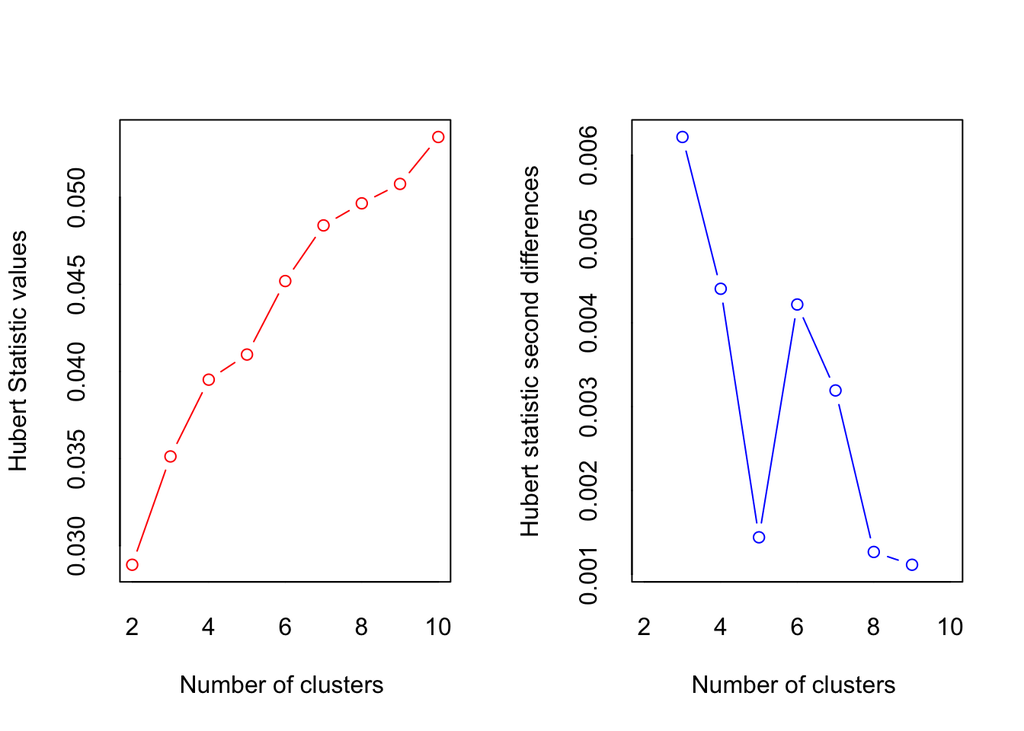

```
## *** : The Hubert index is a graphical method of determining the number of clusters.
##                 In the plot of Hubert index, we seek a significant knee that corresponds to a
##                 significant increase of the value of the measure i.e the significant peak in Hubert
##                 index second differences plot.
##
```

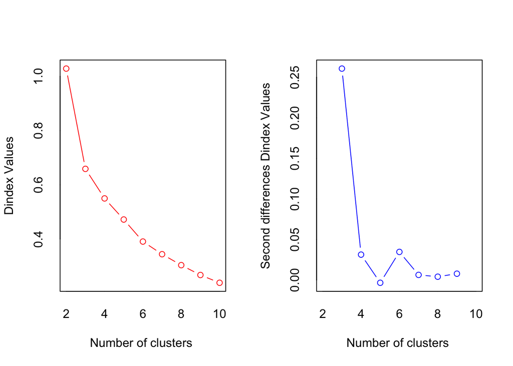

```
## *** : The D index is a graphical method of determining the number of clusters.
##                 In the plot of D index, we seek a significant knee (the significant peak in Dindex
##                 second differences plot) that corresponds to a significant increase of the value of
##                 the measure.
##
## * Among all indices:
## * 4 proposed 2 as the best number of clusters
## * 9 proposed 3 as the best number of clusters
## * 2 proposed 4 as the best number of clusters
## * 3 proposed 6 as the best number of clusters
## * 5 proposed 10 as the best number of clusters
##
##                    ***** Conclusion *****
##
## * According to the majority rule, the best number of clusters is  3
##
##
```

```r
set.seed(123)
# Compute
library("NbClust")
res.nbclust <- obser_final %>%
 scale() %>%
 NbClust(distance = "euclidean",
         min.nc = 2, max.nc = 10,
         method = "complete", index ="all")
```

```
## Among all indices:
## ===================
## * 2 proposed  0 as the best number of clusters
## * 1 proposed  1 as the best number of clusters
## * 4 proposed  2 as the best number of clusters
## * 9 proposed  3 as the best number of clusters
## * 2 proposed  4 as the best number of clusters
## * 3 proposed  6 as the best number of clusters
## * 5 proposed  10 as the best number of clusters
##
## Conclusion
## =========================
## * According to the majority rule, the best number of clusters is  3 .
```

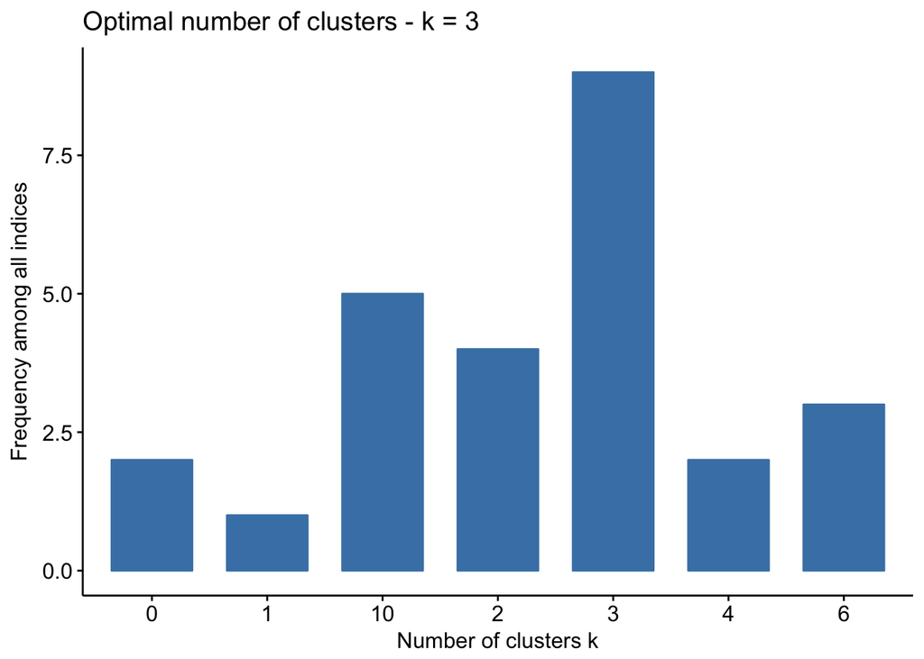

```r
library(factoextra)
fviz_nbclust(res.nbclust, ggtheme = theme_minimal())
```

# Clustering validation statistics

A variety of measures has been proposed in the literature for evaluating clustering results. The term clustering validation is used to design the procedure of evaluating the results of a clustering algorithm.

The silhouette plot is one of the many measures for inspecting and validating clustering results. Recall that the silhouette (Si ) measures how similar an object i is to the the other objects in its own cluster versus those in the neighbor cluster. Si values range from 1 to - 1:

A value of Si close to 1 indicates that the object is well clustered. In the other words, the object i is similar to the other objects in its group. A value of Si close to -1 indicates that the object is poorly clustered, and that assignment to some other cluster would probably improve the overall results. In the following R code, we???ll compute and evaluate the result of hierarchical clustering methods.

Compute and visualize hierarchical clustering:

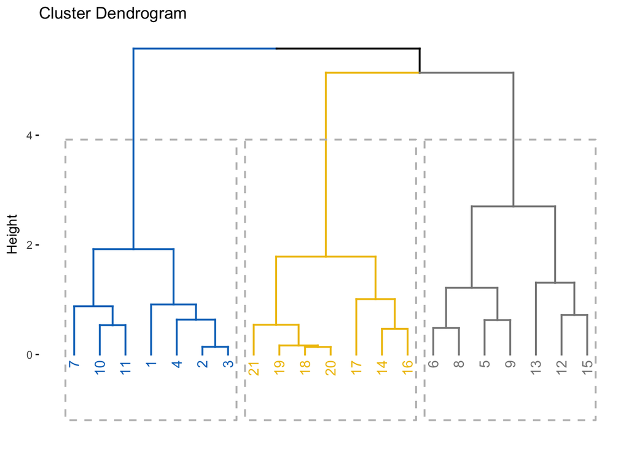

```r
set.seed(123)
# Enhanced hierarchical clustering, cut in 3 groups
res.hc <- obser_final[,] %>%
 scale() %>%
 eclust("hclust", k = 3, graph = FALSE)
# Visualize with factoextra
fviz_dend(res.hc, palette = "jco",
         rect = TRUE, show_labels = TRUE)
```

```
##   cluster size ave.sil.width
## 1       1    7          0.50
## 2       2    7          0.28
## 3       3    7          0.59
```

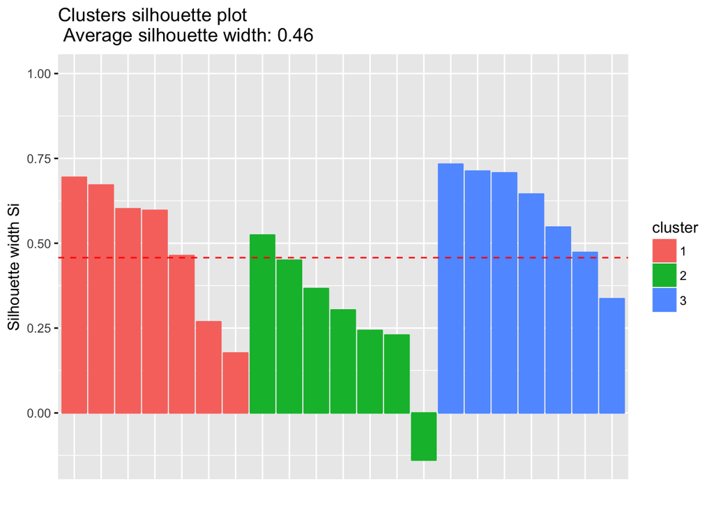

```r
fviz_silhouette(res.hc)
```

Which samples have negative silhouette? To what cluster are they closer?

```r
# Silhouette width of observations
sil <- res.hc$silinfo$widths[, 1:3]
# Objects with negative silhouette
neg_sil_index <- which(sil[, 'sil_width'] < 0)
sil[neg_sil_index, , drop = FALSE]
```

```
##   cluster neighbor  sil_width
## 6       2        1 -0.1389937
```

# Visualize the final clustered data

```r
vis_data = obser_final %>%
 group_by(sil$cluster)

vis_data1 = obser_final %>%
 group_by(sil$cluster)  %>% summarise(
   s_count_n = n()
 )

vis_data1
```

```
## # A tibble: 3 x 2
##   `sil$cluster` s_count_n
##          <fctr>     <int>
## 1             1         7
## 2             2         7
## 3             3         7
```

The below plot shows the three different clusters formed in our data and how the data is spread over the ID’s and the Sum of time spent in each cluster.

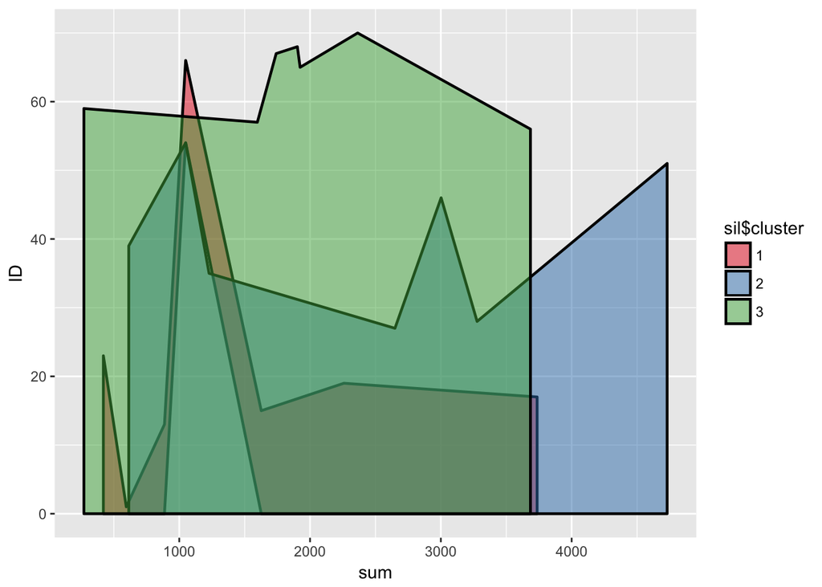

```r
ggplot(vis_data,aes(x=sum,y=ID,fill=sil$cluster)) + geom_area(colour="black", size=0.8, alpha=.5) + scale_fill_brewer(palette="Set1")
```

# CONCLUSION

Our clustering is based on the table for which we have filtered the data based on the following

```
-category of the exhibit(only the people who are attending the exhibit are considered)
-Parent's tiredness influences the category of the exhibit, if they are tired they are not visiting the exhibit
-So, we are considering only the data for which the parent's mood is good, hence the bad mood data is filtered.
-Found the most visited galleries based on the count of the visit, got the top 3
-Calculated the total time spent by each ID for the above filtered data.
```

[output not shown]

The number of clusters considered for our data is 3, which is proved to be optimal by the use of NbClust.